# Intermediate Python for Data Science

- 2017-10-13
- William Surles
- Course notes from datacamp

## Load all needed packages and datasets

```python
import matplotlib.pyplot as plt
import pandas as pd
import numpy as np
import pprint
pp = pprint.PrettyPrinter()
```

```python
run create_datasets.py
```

# Matplotlib

## Basic plots with matplotlib

- Python is pretty lazy. It won't display the plot until you run `plt.show()`
  - After creating the plot I can add things to it before showing.

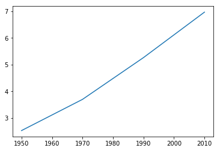

```python
year_small = [1950, 1970, 1990, 2010]
pop_small = [2.519, 3.692, 5.263, 6.972]
plt.plot(year_small, pop_small)
plt.show()
```

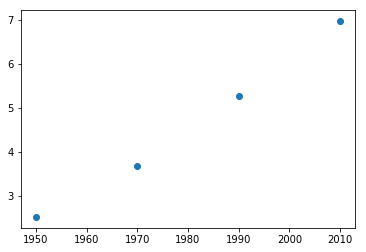

```python
plt.scatter(year_small, pop_small)
plt.show()
```

### Line plot (1)

```
2100
10.85
```

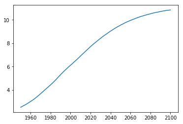

```python
# Print the last item from year and pop
print(year1[-1])
print(pop1[-1])

# Make a line plot: year on the x-axis, pop on the y-axis
plt.plot(year1, pop1)

# Display the plot with plt.show()
plt.show()
```

### Line plot (3)

```python
gapminder = pd.read_csv('https://assets.datacamp.com/production/course_799/datasets/gapminder.csv')
```

```python
gapminder.head()
```

|  | Unnamed: 0 | country | year | population | cont | life_exp | gdp_cap |
| --- | --- | --- | --- | --- | --- | --- | --- |
| 0 | 11 | Afghanistan | 2007 | 31889923.0 | Asia | 43.828 | 974.580338 |
| 1 | 23 | Albania | 2007 | 3600523.0 | Europe | 76.423 | 5937.029526 |
| 2 | 35 | Algeria | 2007 | 33333216.0 | Africa | 72.301 | 6223.367465 |
| 3 | 47 | Angola | 2007 | 12420476.0 | Africa | 42.731 | 4797.231267 |
| 4 | 59 | Argentina | 2007 | 40301927.0 | Americas | 75.320 | 12779.379640 |

```python
life_exp = gapminder['life_exp'].tolist()
gdp_cap = gapminder['gdp_cap'].tolist()
pop = gapminder['population'].tolist()
```

```
43.486999999999995
469.70929810000007
```

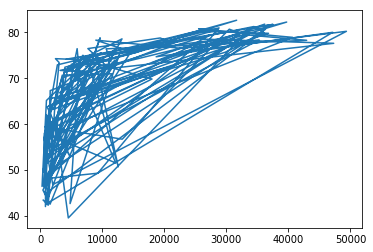

```python
# Print the last item of gdp_cap and life_exp
print(life_exp[-1])
print(gdp_cap[-1])

# Make a line plot, gdp_cap on the x-axis, life_exp on the y-axis
plt.plot(gdp_cap, life_exp)

# Display the plot
plt.show()
```

- Well, that looks a little funky

### Scatter Plot (1)

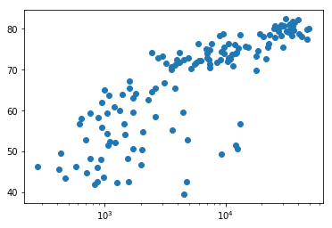

```python
# Change the line plot below to a scatter plot
plt.scatter(gdp_cap, life_exp)

# Put the x-axis on a logarithmic scale
plt.xscale('log')

# Show plot
plt.show()
```

### Scatter plot (2)

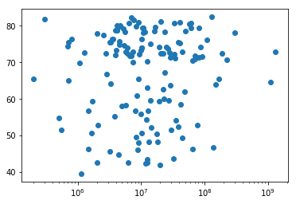

```python
# Build Scatter plot
plt.scatter(pop, life_exp)
plt.xscale('log')

# Show plot
plt.show()
```

- There does not appear to be a correlation between population and life expectancy

## Histograms

### Build a histogram (1)

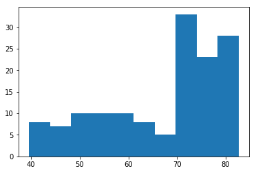

```python
# Create histogram of life_exp data
life_exp

# Display histogram
plt.hist(life_exp)
plt.show()
```

### Build a histogram (2): bins

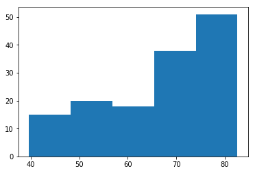

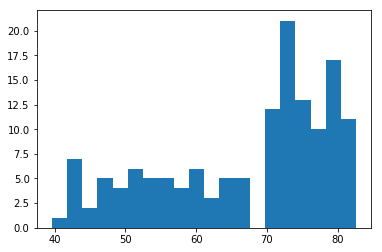

```python
# Build histogram with 5 bins
plt.hist(life_exp, bins = 5)

# Show and clean up plot
plt.show()
plt.clf()

# Build histogram with 20 bins
plt.hist(life_exp, bins = 20)

# Show and clean up again
plt.show()
plt.clf()
```

### Build a histogram (3): compare

- Here we want to compare the life expactancey from 1950 to 2007.
- The gapminder data for the class only has 2007 data
- I'll need to export and load the 1950 data

```python
gapminder.year.unique()
```

```
array([2007])
```

```python
gapminder.shape
```

```
(142, 7)
```

```python
len(life_exp1950)
```

```
142
```

- Alright, this should work now

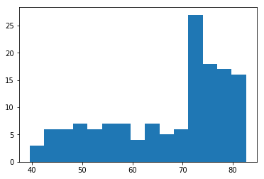

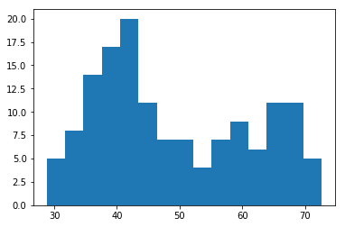

```python
# Histogram of life_exp, 15 bins
plt.hist(life_exp, bins=15)

# Show and clear plot
plt.show()
plt.clf()

# Histogram of life_exp1950, 15 bins
plt.hist(life_exp1950, bins=15)

# Show and clear plot again
plt.show()
plt.clf()
```

## Customization

### Labels

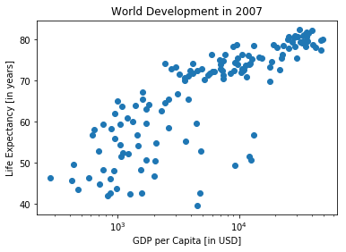

```python
# Basic scatter plot, log scale
plt.scatter(gdp_cap, life_exp)
plt.xscale('log')

# Strings
xlab = 'GDP per Capita [in USD]'
ylab = 'Life Expectancy [in years]'
title = 'World Development in 2007'

# Add axis labels
plt.xlabel(xlab)
plt.ylabel(ylab)

# Add title
plt.title(title)

# After customizing, display the plot
plt.show()
```

### Ticks

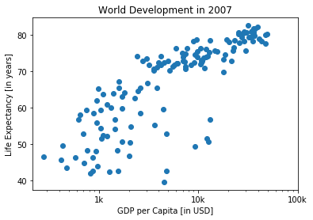

```python
# Scatter plot
plt.scatter(gdp_cap, life_exp)

# Previous customizations
plt.xscale('log')
plt.xlabel('GDP per Capita [in USD]')
plt.ylabel('Life Expectancy [in years]')
plt.title('World Development in 2007')

# Definition of tick_val and tick_lab
tick_val = [1000,10000,100000]
tick_lab = ['1k','10k','100k']

# Adapt the ticks on the x-axis
plt.xticks(tick_val, tick_lab)

# After customizing, display the plot
plt.show()
```

### Sizes

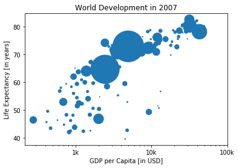

```python
# Store pop as a numpy array: np_pop
np_pop = np.array(pop)

# change population to be in millions and then double
np_pop = np_pop / 1000000 * 2

# Update: set s argument to np_pop
plt.scatter(gdp_cap, life_exp, s = np_pop)

# Previous customizations
plt.xscale('log')
plt.xlabel('GDP per Capita [in USD]')
plt.ylabel('Life Expectancy [in years]')
plt.title('World Development in 2007')
plt.xticks([1000, 10000, 100000],['1k', '10k', '100k'])

# Display the plot
plt.show()
```

### Colors

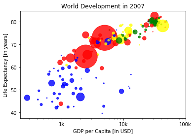

```python
# Specify c and alpha inside plt.scatter()
plt.scatter(
    x = gdp_cap,
    y = life_exp,
    s = np_pop,
    c = col,
    alpha = 0.8)

# Previous customizations
plt.xscale('log')
plt.xlabel('GDP per Capita [in USD]')
plt.ylabel('Life Expectancy [in years]')
plt.title('World Development in 2007')
plt.xticks([1000,10000,100000], ['1k','10k','100k'])

# Show the plot
plt.show()
```

### Additional Customizations

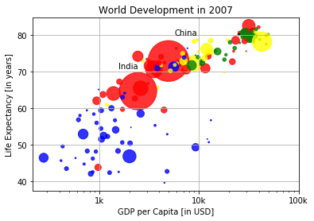

```python
# Scatter plot
plt.scatter(
    x = gdp_cap,
    y = life_exp,
    s = np_pop,
    c = col,
    alpha = 0.8)

# Previous customizations
plt.xscale('log')
plt.xlabel('GDP per Capita [in USD]')
plt.ylabel('Life Expectancy [in years]')
plt.title('World Development in 2007')
plt.xticks([1000,10000,100000], ['1k','10k','100k'])

# Additional customizations
plt.text(1550, 71, 'India')
plt.text(5700, 80, 'China')

# Add grid() call
plt.grid(True)

# Show the plot
plt.show()
```

### Interpretation

The countries in blue, corresponding to Africa, have both low life expectancy and low GDP per capita.

# Dictionaries & Pandas

## Dictionaries, Part 1

### Motivation for dictionaries

This is the long way using two lists. This is not efficient.

```python
# Definition of countries and capital
countries = ['spain', 'france', 'germany', 'norway']
capitals = ['madrid', 'paris', 'berlin', 'oslo']

# Get index of 'germany': ind_ger
ind_ger = countries.index('germany')

# Use ind_ger to print out capital of Germany
print(capitals[ind_ger])
```

```
berlin
```

### Create dictionary

```python
# Definition of countries and capital
countries = ['spain', 'france', 'germany', 'norway']
capitals = ['madrid', 'paris', 'berlin', 'oslo']

# From string in countries and capitals, create dictionary europe
europe = {'spain':'madrid',
          'france':'paris',
          'germany':'berlin',
          'norway':'oslo'}

# Print europe
print(europe)
```

```
{'spain': 'madrid', 'france': 'paris', 'germany': 'berlin', 'norway': 'oslo'}
```

### Access dictionary

Just use the key as the index

```python
# Print out the keys in europe
print(europe.keys())

# Print out value that belongs to key 'norway'
print(europe['norway'])
```

```
dict_keys(['spain', 'france', 'germany', 'norway'])
oslo
```

## Dictionaries, Part 2

- if you add two of the same keys to a dictionary, only the last one will be kept
- keys must be immutable objects.
  - i.e. the key can't be a list.
  - but you can use a string, boolean, or integer

### Dictionary Manipulation (1)

```python
# Add italy to europe
europe['italy'] = 'rome'

# Print out italy in europe
print('italy' in europe)

# Add poland to europe
europe['poland'] = 'warsaw'

# Print europe
pp.pprint(europe)
```

```
True
{'france': 'paris',
 'germany': 'berlin',
 'italy': 'rome',
 'norway': 'oslo',
 'poland': 'warsaw',
 'spain': 'madrid'}
```

### Dictionary Manipulation (2)

```python
# Definition of dictionary
europe = {'spain':'madrid', 'france':'paris', 'germany':'bonn',
          'norway':'oslo', 'italy':'rome', 'poland':'warsaw',
          'australia':'vienna' }
print(europe)
```

```
{'spain': 'madrid', 'france': 'paris', 'germany': 'bonn', 'norway': 'oslo', 'italy': 'rome', 'poland': 'warsaw', 'australia': 'vienna'}
```

```python
# Update capital of germany
europe['germany'] = 'berlin'
print(europe)
```

```
{'spain': 'madrid', 'france': 'paris', 'germany': 'berlin', 'norway': 'oslo', 'italy': 'rome', 'poland': 'warsaw', 'australia': 'vienna'}
```

```python
# Remove australia
del(europe['australia'])
print(europe)
```

```
{'spain': 'madrid', 'france': 'paris', 'germany': 'berlin', 'norway': 'oslo', 'italy': 'rome', 'poland': 'warsaw'}
```

### Dictionariception

```python
# Dictionary of dictionaries
europe = { 'spain': { 'capital':'madrid', 'population':46.77 },
           'france': { 'capital':'paris', 'population':66.03 },
           'germany': { 'capital':'berlin', 'population':80.62 },
           'norway': { 'capital':'oslo', 'population':5.084 } }


# Print out the capital of France
print(europe['france']['capital'])
```

```
paris
```

```python
# Create sub-dictionary data
data = {'capital':'rome','population':59.83}

# Add data to europe under key 'italy'
europe['italy'] = data

# Print europe
pp.pprint(europe)
```

```
{'france': {'capital': 'paris', 'population': 66.03},
 'germany': {'capital': 'berlin', 'population': 80.62},
 'italy': {'capital': 'rome', 'population': 59.83},
 'norway': {'capital': 'oslo', 'population': 5.084},
 'spain': {'capital': 'madrid', 'population': 46.77}}
```

## Pandas, Part 1

- Its very common to have many variables of different types for an observation
  - i.e. you may have country name, area, population, and true or false for something
  - Here a 2D nupy array is not an option to store all of the data because it can only have data of one type. Its more like a matrix. What we need is a data frame. Hello Pandas.
- Pandas is build on numpy

### Dictionary to DataFrame (1)

```python
# Pre-defined lists
names = ['United States', 'Australia', 'Japan', 'India', 'Russia', 'Morocco', 'Egypt']
dr =  [True, False, False, False, True, True, True]
cpc = [809, 731, 588, 18, 200, 70, 45]

# pandas is already imported

# Create dictionary my_dict with three key:value pairs: my_dict
my_dict = {
    'country': names,
    'drives_right': dr,
    'cars_per_cap': cpc
    }

# Build a DataFrame cars from my_dict: cars
cars = pd.DataFrame(my_dict)

# Print cars
print(cars)
```

```
   cars_per_cap        country  drives_right
0           809  United States          True
1           731      Australia         False
2           588          Japan         False
3            18          India         False
4           200         Russia          True
5            70        Morocco          True
6            45          Egypt          True
```

### Dictionary to DataFrame (2)

```python
# Build cars DataFrame
names = ['United States', 'Australia', 'Japan', 'India', 'Russia', 'Morocco', 'Egypt']
dr =  [True, False, False, False, True, True, True]
cpc = [809, 731, 588, 18, 200, 70, 45]

dict = { 'country':names, 'drives_right':dr, 'cars_per_cap':cpc }

cars = pd.DataFrame(dict)

print(cars)

# Definition of row_labels
row_labels = ['US', 'AUS', 'JAP', 'IN', 'RU', 'MOR', 'EG']

# Specify row labels of cars
cars.index = row_labels

# Print cars again
print(cars)
```

```
   cars_per_cap        country  drives_right
0           809  United States          True
1           731      Australia         False
2           588          Japan         False
3            18          India         False
4           200         Russia          True
5            70        Morocco          True
6            45          Egypt          True
     cars_per_cap        country  drives_right
US            809  United States          True
AUS           731      Australia         False
JAP           588          Japan         False
IN             18          India         False
RU            200         Russia          True
MOR            70        Morocco          True
EG             45          Egypt          True
```

### CSV to DataFrame (1)

```python
# Import cars from csv
cars = pd.read_csv('https://assets.datacamp.com/production/course_799/datasets/cars.csv')
print(cars)
```

```
  Unnamed: 0  cars_per_cap        country  drives_right
0         US           809  United States          True
1        AUS           731      Australia         False
2        JAP           588          Japan         False
3         IN            18          India         False
4         RU           200         Russia          True
5        MOR            70        Morocco          True
6         EG            45          Egypt          True
```

### CSV to DataFrame (2)

```python
# Fix import by including index_col
cars = pd.read_csv('https://assets.datacamp.com/production/course_799/datasets/cars.csv', index_col=0)
print(cars)
```

```
     cars_per_cap        country  drives_right
US            809  United States          True
AUS           731      Australia         False
JAP           588          Japan         False
IN             18          India         False
RU            200         Russia          True
MOR            70        Morocco          True
EG             45          Egypt          True
```

## Pandas, Part 2

- Row labels are important for indexing in pandas
- You can use double brackets to select columns or single to select a slice of rows
  - But this is all a bit limited.
- `loc` and `iloc` are much more verstile for selecting parts of a dataframe
  - `loc` is the pandas way to select based on labels
  - `iloc` is for integer position-based selection
  - this is similar to using `my_array[rows, columns]` indexing with numpy arrays
  - still need to use double brackets the have the data in a dataframe or display
  - you can select rows and columns at the same time

### Square Brackets (1)

```python
cars.head()
```

|  | cars_per_cap | country | drives_right |
| --- | --- | --- | --- |
| US | 809 | United States | True |
| AUS | 731 | Australia | False |
| JAP | 588 | Japan | False |
| IN | 18 | India | False |
| RU | 200 | Russia | True |

```python
# Print out country column as Pandas Series
print(cars['country'])
```

```
US     United States
AUS        Australia
JAP            Japan
IN             India
RU            Russia
MOR          Morocco
EG             Egypt
Name: country, dtype: object
```

```python
# Print out country column as Pandas DataFrame
print(cars[['country']])
```

```
           country
US   United States
AUS      Australia
JAP          Japan
IN           India
RU          Russia
MOR        Morocco
EG           Egypt
```

```python
# Print out DataFrame with country and drives_right columns
print(cars[['country','drives_right']])
```

```
           country  drives_right
US   United States          True
AUS      Australia         False
JAP          Japan         False
IN           India         False
RU          Russia          True
MOR        Morocco          True
EG           Egypt          True
```

### Square Brackets (2)

```python
# Print out first 3 observations
print(cars[0:3])
```

```
     cars_per_cap        country  drives_right
US            809  United States          True
AUS           731      Australia         False
JAP           588          Japan         False
```

```python
# Print out fourth, fifth and sixth observation
print(cars[3:6])
```

```
     cars_per_cap  country  drives_right
IN             18    India         False
RU            200   Russia          True
MOR            70  Morocco          True
```

### loc and iloc (1)

```python
# Print out observation for Japan
print(cars.loc['JAP'])
```

```
cars_per_cap      588
country         Japan
drives_right    False
Name: JAP, dtype: object
```

```python
# Print out observations for Australia and Egypt
print(cars.loc[['AUS','EG']])
```

```
     cars_per_cap    country  drives_right
AUS           731  Australia         False
EG             45      Egypt          True
```

### loc and iloc (2)

```python
# Print out drives_right value of Morocco
print(cars.loc[['MOR'],['drives_right']])
```

```
     drives_right
MOR          True
```

```python
# Print sub-DataFrame
print(cars.loc[['RU','MOR'],['country','drives_right']])
```

```
     country  drives_right
RU    Russia          True
MOR  Morocco          True
```

### loc and iloc (3)

```python
# Print out drives_right column as Series
print(cars.loc[:, 'drives_right'])
```

```
US      True
AUS    False
JAP    False
IN     False
RU      True
MOR     True
EG      True
Name: drives_right, dtype: bool
```

```python
# Print out drives_right column as DataFrame
print(cars.loc[:, ['drives_right']])
```

```
     drives_right
US           True
AUS         False
JAP         False
IN          False
RU           True
MOR          True
EG           True
```

```python
# Print out cars_per_cap and drives_right as DataFrame
print(cars.loc[:, ['cars_per_cap','drives_right']])
```

```
     cars_per_cap  drives_right
US            809          True
AUS           731         False
JAP           588         False
IN             18         False
RU            200          True
MOR            70          True
EG             45          True
```

# Logic, Control Flow and Filtering

## Comparison Operators

### Equality

```python
# Comparison of booleans
print(True == False)
```

```
False
```

```python
# Comparison of integers
print(-5 * 15 != 75)
```

```
True
```

```python
# Comparison of strings
print("pyscript" == "PyScript")
```

```
False
```

```python
# Compare a boolean with an integer
print(True == 1)
```

```
True
```

### Greater and less than

```python
# Comparison of integers
x = -3 * 6
print(x >= -10)
```

```
False
```

```python
# Comparison of strings
y = "test"
print("test" <= y)
```

```
True
```

```python
# Comparison of booleans
print(True > False)
```

```
True
```

### Compare arrays

```python
# Create arrays
my_house = np.array([18.0, 20.0, 10.75, 9.50])
your_house = np.array([14.0, 24.0, 14.25, 9.0])
```

```python
# my_house greater than or equal to 18
print(my_house >= 18)
```

```
[ True  True False False]
```

```python
# my_house less than your_house
print(my_house < your_house)
```

```
[False  True  True False]
```

## Boolean Operators

### and, or, not (1)

```python
# Define variables
my_kitchen = 18.0
your_kitchen = 14.0
```

```python
# my_kitchen bigger than 10 and smaller than 18?
print(my_kitchen > 10 and my_kitchen < 18)
```

```
False
```

```python
# my_kitchen smaller than 14 or bigger than 17?
print(my_kitchen < 14 or my_kitchen > 17)
```

```
True
```

```python
# Double my_kitchen smaller than triple your_kitchen?
print(2 * my_kitchen < 3 * your_kitchen)
```

```
True
```

### and, or, not (2)

```python
x = 8
y = 9
not(not(x < 3) and not(y > 14 or y > 10))
```

```
False
```

### Boolean operators with Numpy

- `and`, `or`, and `not` do not work on numpy arrays
- Instead use the functions `locigal_and()`, `locigal_or()`, `locigal_not()`

```python
# Create arrays
my_house = np.array([18.0, 20.0, 10.75, 9.50])
your_house = np.array([14.0, 24.0, 14.25, 9.0])
```

```python
# my_house greater than 18.5 or smaller than 10
print(np.logical_or(my_house > 18.5, my_house < 10))
```

```
[False  True False  True]
```

```python
# Both my_house and your_house smaller than 11
print(np.logical_and(my_house < 11, your_house < 11))
```

```
[False False False  True]
```

## if, elif, else

### Warmup

```python
area = 10.0
if(area < 9) :
    print("small")
elif(area < 12) :
    print("medium")
else :
    print("large")
```

```
medium
```

### if

```python
# Define variables
room = "kit"
area = 14.0

# if statement for room
if room == "kit" :
    print("looking around in the kitchen.")

# if statement for area
if area > 15:
    print("big place!")
```

```
looking around in the kitchen.
```

### Add else

```python
# Define variables
room = "kit"
area = 14.0

# if-else construct for room
if room == "kit" :
    print("looking around in the kitchen.")
else :
    print("looking around elsewhere.")

# if-else construct for area
if area > 15 :
    print("big place!")
else:
    print("pretty small.")
```

```
looking around in the kitchen.
pretty small.
```

### Customize further: elif

```python
# Define variables
room = "bed"
area = 14.0

# if-elif-else construct for room
if room == "kit" :
    print("looking around in the kitchen.")
elif room == "bed":
    print("looking around in the bedroom.")
else :
    print("looking around elsewhere.")

# if-elif-else construct for area
if area > 15 :
    print("big place!")
elif area > 10:
    print("medium size, nice!")
else :
    print("pretty small.")
```

```
looking around in the bedroom.
medium size, nice!
```

## Filtering Pandas DataFrame

### Driving right (1)

```python
# Cars is already loaded
cars.head()
```

|  | cars_per_cap | country | drives_right |
| --- | --- | --- | --- |
| US | 809 | United States | True |
| AUS | 731 | Australia | False |
| JAP | 588 | Japan | False |
| IN | 18 | India | False |
| RU | 200 | Russia | True |

```python
# Extract drives_right column as Series: dr
dr = cars["drives_right"]

# Use dr to subset cars: sel
sel = cars[dr]
print(sel)
```

```
     cars_per_cap        country  drives_right
US            809  United States          True
RU            200         Russia          True
MOR            70        Morocco          True
EG             45          Egypt          True
```

### Driving right (2)

```python
# Convert code to a one-liner
sel = cars[cars['drives_right']]

# Print sel
print(sel)
```

```
     cars_per_cap        country  drives_right
US            809  United States          True
RU            200         Russia          True
MOR            70        Morocco          True
EG             45          Egypt          True
```

### Cars per capita (1)

```python
# Create car_maniac: observations that have a cars_per_cap over 500
cpc = cars["cars_per_cap"]
many_cars = cpc > 500
car_maniac = cars[many_cars]

# Print car_maniac
print(car_maniac)
```

```
     cars_per_cap        country  drives_right
US            809  United States          True
AUS           731      Australia         False
JAP           588          Japan         False
```

### Cars per capita (2)

```python
# Create medium: observations with cars_per_cap between 100 and 500
cpc = cars["cars_per_cap"]
between = np.logical_and(cpc > 100, cpc < 500)
medium = cars[between]

# Print medium
print(medium)
```

```
    cars_per_cap country  drives_right
RU           200  Russia          True
```

# Loops

## while loop

### while: warming up

```python
x = 1
while x < 4 :
    print(x)
    x = x + 1
```

```
1
2
3
```

### Basic while loop

```python
error = 50.0
while error > 1 :
    error = error / 4
    print(error)
```

```
12.5
3.125
0.78125
```

```python
# Initialize offset
offset = 8

# Code the while loop
while offset != 0:
    print("correcting...")
    offset = offset - 1
    print(offset)
```

```
correcting...
7
correcting...
6
correcting...
5
correcting...
4
correcting...
3
correcting...
2
correcting...
1
correcting...
0
```

### Add conditionals

```python
# Initialize offset
offset = -6

# Code the while loop
while offset != 0 :
    print("correcting...")

    if offset > 0:
        offset = offset - 1
    else:
        offset = offset + 1

    print(offset)
```

```
correcting...
-5
correcting...
-4
correcting...
-3
correcting...
-2
correcting...
-1
correcting...
0
```

## for loop

### Loop over a list

```python
# areas list
areas = [11.25, 18.0, 20.0, 10.75, 9.50]

# Code the for loop
for item in areas:
    print(item)
```

```
11.25
18.0
20.0
10.75
9.5
```

### Indexes and values (1)

Using `enumerate` gives us access to the index also. Sometimes this is useful.

```python
# areas list
areas = [11.25, 18.0, 20.0, 10.75, 9.50]

# Change for loop to use enumerate()
for index, value in enumerate(areas):
    print("room " + str(index) + ": " + str(value))
```

```
room 0: 11.25
room 1: 18.0
room 2: 20.0
room 3: 10.75
room 4: 9.5
```

### Indexes and values (2)

Just adding a one to the index print statement so we don't have room 0

```python
# areas list
areas = [11.25, 18.0, 20.0, 10.75, 9.50]

# Code the for loop
for index, area in enumerate(areas) :
    print("room " + str(index + 1) + ": " + str(area))
```

```
room 1: 11.25
room 2: 18.0
room 3: 20.0
room 4: 10.75
room 5: 9.5
```

### Loop over list of lists

```python
# house list of lists
house = [["hallway", 11.25],
         ["kitchen", 18.0],
         ["living room", 20.0],
         ["bedroom", 10.75],
         ["bathroom", 9.50]]

# Build a for loop from scratch

for item in (house):
    print("the " + item[0] + " is " + str(item[1]) + " sqm")
```

```
the hallway is 11.25 sqm
the kitchen is 18.0 sqm
the living room is 20.0 sqm
the bedroom is 10.75 sqm
the bathroom is 9.5 sqm
```

## Looping Data Structures, Part 1

- Looping over a dictionary requires a method. Looping a numpy array requires a function.
- Dictionaries are not ordered so any item could be first

### Loop over dictionary

```python
# Definition of dictionary
europe = {'spain':'madrid', 'france':'paris', 'germany':'bonn',
          'norway':'oslo', 'italy':'rome', 'poland':'warsaw', 'australia':'vienna' }

# Iterate over europe
for key, value in europe.items():
    print("the capital of " + key + " is " + str(value))
```

```
the capital of spain is madrid
the capital of france is paris
the capital of germany is bonn
the capital of norway is oslo
the capital of italy is rome
the capital of poland is warsaw
the capital of australia is vienna
```

### Loop over Numpy array

It will iterate through the first column or 'list', then the second, and so on.

```python
# Create a np array of heights
height = [1.73, 1.68, 1.71, 1.89, 1.79]
np_height = np.array(height)
```

```python
# For loop over np_height
for x in np_height:
    print(str(x) + " inches")
```

```
1.73 inches
1.68 inches
1.71 inches
1.89 inches
1.79 inches
```

```python
# Create a 2D Numpy array from baseball: np_baseball
np_baseball = np.array(
    [[180, 78.4],
     [215, 102.7],
     [210, 98.5],
     [188, 75.2]])
```

```python
# For loop over np_baseball
for x in np.nditer(np_baseball):
    print(str(x))
```

```
180.0
78.4
215.0
102.7
210.0
98.5
188.0
75.2
```

```python
np_baseball_2 = np.array(
    [[1.73, 1.68, 1.71, 1.89, 1.79],
     [65.4, 59.2, 63.6, 88.4, 68.7]])
np_baseball_2
```

```
array([[  1.73,   1.68,   1.71,   1.89,   1.79],
       [ 65.4 ,  59.2 ,  63.6 ,  88.4 ,  68.7 ]])
```

```python
for x in np.nditer(baseball_2):
    print(str(x))
```

```
1.73
1.68
1.71
1.89
1.79
65.4
59.2
63.6
88.4
68.7
```

## Looping Data Structures, Part 2

### Loop over DataFrame (1)

```python
# cars is already loaded
cars.head()
```

|  | cars_per_cap | country | drives_right |
| --- | --- | --- | --- |
| US | 809 | United States | True |
| AUS | 731 | Australia | False |
| JAP | 588 | Japan | False |
| IN | 18 | India | False |
| RU | 200 | Russia | True |

```python
# Iterate over rows of cars
for lab, row in cars.iterrows():
    print(lab)
    print(row)
```

```
US
cars_per_cap              809
country         United States
drives_right             True
Name: US, dtype: object
AUS
cars_per_cap          731
country         Australia
drives_right        False
Name: AUS, dtype: object
JAP
cars_per_cap      588
country         Japan
drives_right    False
Name: JAP, dtype: object
IN
cars_per_cap       18
country         India
drives_right    False
Name: IN, dtype: object
RU
cars_per_cap       200
country         Russia
drives_right      True
Name: RU, dtype: object
MOR
cars_per_cap         70
country         Morocco
drives_right       True
Name: MOR, dtype: object
EG
cars_per_cap       45
country         Egypt
drives_right     True
Name: EG, dtype: object
```

### Loop over DataFrame (2)

```python
# Adapt for loop
for lab, row in cars.iterrows() :
    print(lab + ': ' + str(row['cars_per_cap']))
```

```
US: 809
AUS: 731
JAP: 588
IN: 18
RU: 200
MOR: 70
EG: 45
```

### Add column (1)

```python
# Code for loop that adds COUNTRY column
for lab, row in cars.iterrows() :
    cars.loc[lab, "COUNTRY"] = row["country"].upper()

# Print cars
print(cars)
```

```
     cars_per_cap        country  drives_right        COUNTRY
US            809  United States          True  UNITED STATES
AUS           731      Australia         False      AUSTRALIA
JAP           588          Japan         False          JAPAN
IN             18          India         False          INDIA
RU            200         Russia          True         RUSSIA
MOR            70        Morocco          True        MOROCCO
EG             45          Egypt          True          EGYPT
```

### Add column (2)

```python
# Use .apply(str.upper)
cars["COUNTRY"] = cars["country"].apply(str.upper)
print(cars)
```

```
     cars_per_cap        country  drives_right        COUNTRY
US            809  United States          True  UNITED STATES
AUS           731      Australia         False      AUSTRALIA
JAP           588          Japan         False          JAPAN
IN             18          India         False          INDIA
RU            200         Russia          True         RUSSIA
MOR            70        Morocco          True        MOROCCO
EG             45          Egypt          True          EGYPT
```

# Case Study: Hacker Statistics

## Random Numbers

Here is an example with a coin flip:

```python
np.random.seed(123)
coin = np.random.randint(0,2)
print(coin)
if coin == 0:
    print("heads")
else:
    print("tails")
```

```
0
heads
```

### Random float

```python
# Set the seed
np.random.seed(123)

# Generate and print random float
print(np.random.rand())
```

```
0.6964691855978616
```

### Roll the dice

```python
np.random.seed(123)

# Use randint() to simulate a dice
print(np.random.randint(1,7))

# Use randint() again
print(np.random.randint(1,7))
```

```
6
3
```

### Determine your next move

```python
np.random.seed(123)

# Starting step
step = 50

# Roll the dice
dice = np.random.randint(1,7)

# Finish the control construct
if dice <= 2 :
    step = step - 1
elif dice <= 5 :
    step = step + 1
else :
    step = step + np.random.randint(1,7)

# Print out dice and step
print(dice)
print(step)
```

```
6
53
```

## Random Walk

Here is an example with 10 coin flips: This example is not a 'walk' because the value of the current step is not based on the previous steps.

```python
np.random.seed(123)
outcomes = []
for x in range(10):
    coin = np.random.randint(0,2)
    if coin == 0:
        outcomes.append("heads")
    else:
        outcomes.append("tails")
print(outcomes)
```

```
['heads', 'tails', 'heads', 'heads', 'heads', 'heads', 'heads', 'tails', 'tails', 'heads']
```

In this case we do use a random walk because the current value depends on what happened before. Here we simply keep track of the total number of tails.

```python
np.random.seed(123)
tails = [0]
for x in range(10):
    coin = np.random.randint(0,2)
    tails.append(tails[x] + coin)
print(tails)
```

```
[0, 0, 1, 1, 1, 1, 1, 1, 2, 3, 3]
```

### The next step

```python
np.random.seed(123)

# Initialize random_walk
random_walk = [0]

# Complete the ___
for x in range(100) :
    # Set step: last element in random_walk
    step = random_walk[-1]

    # Roll the dice
    dice = np.random.randint(1,7)

    # Determine next step
    if dice <= 2:
        step = step - 1
    elif dice <= 5:
        step = step + 1
    else:
        step = step + np.random.randint(1,7)

    # append next_step to random_walk
    random_walk.append(step)

# Print random_walk
print(random_walk)
```

```
[0, 3, 4, 5, 4, 5, 6, 7, 6, 5, 4, 3, 2, 1, 0, -1, 0, 5, 4, 3, 4, 3, 4, 5, 6, 7, 8, 7, 8, 7, 8, 9, 10, 11, 10, 14, 15, 14, 15, 14, 15, 16, 17, 18, 19, 20, 21, 24, 25, 26, 27, 32, 33, 37, 38, 37, 38, 39, 38, 39, 40, 42, 43, 44, 43, 42, 43, 44, 43, 42, 43, 44, 46, 45, 44, 45, 44, 45, 46, 47, 49, 48, 49…
```

### How low can you go?

Here we just fix the code below using `max()` so that you can't go below floor 0.

```python
np.random.seed(123)

# Initialize random_walk
random_walk = [0]

for x in range(100) :
    step = random_walk[-1]
    dice = np.random.randint(1,7)

    if dice <= 2:
        # Replace below: use max to make sure step can't go below 0
        step = max(0, step - 1)
    elif dice <= 5:
        step = step + 1
    else:
        step = step + np.random.randint(1,7)

    random_walk.append(step)

print(random_walk)
```

```
[0, 3, 4, 5, 4, 5, 6, 7, 6, 5, 4, 3, 2, 1, 0, 0, 1, 6, 5, 4, 5, 4, 5, 6, 7, 8, 9, 8, 9, 8, 9, 10, 11, 12, 11, 15, 16, 15, 16, 15, 16, 17, 18, 19, 20, 21, 22, 25, 26, 27, 28, 33, 34, 38, 39, 38, 39, 40, 39, 40, 41, 43, 44, 45, 44, 43, 44, 45, 44, 43, 44, 45, 47, 46, 45, 46, 45, 46, 47, 48, 50, 49, 50…
```

### Visualize the walk

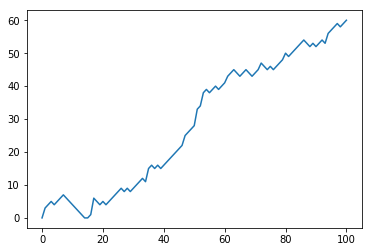

```python
# Initialization
np.random.seed(123)
random_walk = [0]

for x in range(100) :
    step = random_walk[-1]
    dice = np.random.randint(1,7)

    if dice <= 2:
        step = max(0, step - 1)
    elif dice <= 5:
        step = step + 1
    else:
        step = step + np.random.randint(1,7)

    random_walk.append(step)

# Import matplotlib.pyplot as plt
import matplotlib.pyplot as plt

# Plot random_walk
plt.plot(random_walk)

# Show the plot
plt.show()
```

## Distribution

Distribution of tails count from 10 coin flips...

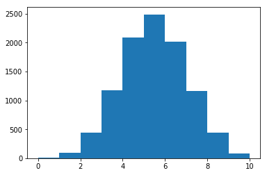

```python
np.random.seed(123)
final_tails = []
for x in range(10000):
    tails = [0]
    for x in range(10):
        coin = np.random.randint(0,2)
        tails.append(tails[x] + coin)
    final_tails.append(tails[-1])
plt.hist(final_tails, bins = 10)
plt.show()
```

The more times you simulate the 10 coin flips, the closer you get to the theoretical bell curve distributions. At 10,000 this is getting pretty close.

### Simulate multiple walks

```python
# Initialization
np.random.seed(123)
all_walks = []

# Simulate random walk 10 times
for i in range(10) :

    # Code from before
    random_walk = [0]
    for x in range(100) :
        step = random_walk[-1]
        dice = np.random.randint(1,7)

        if dice <= 2:
            step = max(0, step - 1)
        elif dice <= 5:
            step = step + 1
        else:
            step = step + np.random.randint(1,7)
        random_walk.append(step)

    # Append random_walk to all_walks
    all_walks.append(random_walk)

# Print all_walks
print(all_walks)
```

```
[[0, 3, 4, 5, 4, 5, 6, 7, 6, 5, 4, 3, 2, 1, 0, 0, 1, 6, 5, 4, 5, 4, 5, 6, 7, 8, 9, 8, 9, 8, 9, 10, 11, 12, 11, 15, 16, 15, 16, 15, 16, 17, 18, 19, 20, 21, 22, 25, 26, 27, 28, 33, 34, 38, 39, 38, 39, 40, 39, 40, 41, 43, 44, 45, 44, 43, 44, 45, 44, 43, 44, 45, 47, 46, 45, 46, 45, 46, 47, 48, 50, 49, 5…
```

### Visualize all walks

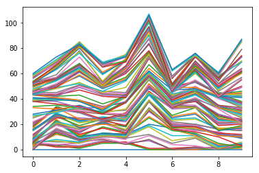

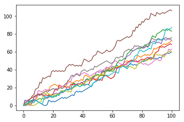

```python
np.random.seed(123)
all_walks = []

for i in range(10) :
    random_walk = [0]
    for x in range(100) :
        step = random_walk[-1]
        dice = np.random.randint(1,7)
        if dice <= 2:
            step = max(0, step - 1)
        elif dice <= 5:
            step = step + 1
        else:
            step = step + np.random.randint(1,7)
        random_walk.append(step)
    all_walks.append(random_walk)

# Convert all_walks to Numpy array: np_aw
np_aw = np.array(all_walks)

# Plot np_aw and show
plt.plot(np_aw)
plt.show()

# Clear the figure
plt.clf()

# Transpose np_aw: np_aw_t
np_aw_t = np.transpose(np_aw)

# Plot np_aw_t and show
plt.plot(np_aw_t)
plt.show()
```

### Implement clumsiness

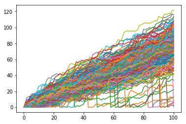

```python
np.random.seed(123)
all_walks = []

# Simulate random walk 250 times
for i in range(250) :
    random_walk = [0]
    for x in range(100) :
        step = random_walk[-1]
        dice = np.random.randint(1,7)
        if dice <= 2:
            step = max(0, step - 1)
        elif dice <= 5:
            step = step + 1
        else:
            step = step + np.random.randint(1,7)

        # Implement clumsiness
        if np.random.rand() <= 0.001 :
            step = 0

        random_walk.append(step)
    all_walks.append(random_walk)

# Create and plot np_aw_t
np_aw_t = np.transpose(np.array(all_walks))
plt.plot(np_aw_t)
plt.show()
```

### Plot the distribution

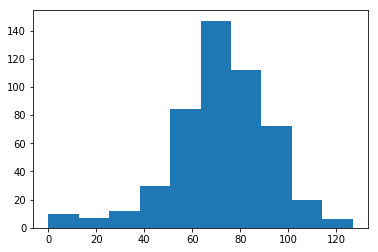

```python
np.random.seed(123)
all_walks = []

# Simulate random walk 500 times
for i in range(500) :
    random_walk = [0]
    for x in range(100) :
        step = random_walk[-1]
        dice = np.random.randint(1,7)
        if dice <= 2:
            step = max(0, step - 1)
        elif dice <= 5:
            step = step + 1
        else:
            step = step + np.random.randint(1,7)
        if np.random.rand() <= 0.001 :
            step = 0
        random_walk.append(step)
    all_walks.append(random_walk)

# Create and plot np_aw_t
np_aw_t = np.transpose(np.array(all_walks))

# Select last row from np_aw_t: ends
ends = np_aw_t[-1]

# Plot histogram of ends, display plot
plt.hist(ends)
plt.show()
```

### Calculate the odds

```python
sum(ends >= 60)/500
```

```
0.78400000000000003
```